# ManyPrimates1_Phylogenetic_Analysis

# NOTE

Running the models takes a long time (12h on a HPC) - outputs are too large to put on GitHub (~7GB). If you want to access the model outputs directly, you have to download them via the following link. Code below expects files to be in `saves/`.

If the code doesn’t work, you can download the files here: `https://keeper.mpdl.mpg.de/f/e78a9963b58f4a9190d8/?dl=1` but you will have to put them manually into the `saves` directory.

```r
# unpack zip file to get .rds files
unzip("../saves/saves.zip", exdir = "../")
```

```
zip file is corrupt
```

# Data processing

## Read in STM data file

```r
data <- read_csv("../data/merged_data/ManyPrimates_mp1_merged_data.csv")
```

## Read in species level predictors and scale them.

Species `hamlyns_monkey` and `allens_swamp_monkey` will be excluded from the phylogenetic analysis because we did not find data for some predictors for those species. For `sichuan_snub_nosed_monkey` we actually don’t have any experimental data.

| species_english | species_latin | family | superordinate_group | color_vision | diet_diversity | vocal_repertoire | resting_time_percent_activitybudget | percent_frugivory | terrestriality | group_size | home_range | body_size | feeding_budget | dietary_breadth | day_journey_length | home_range_body_site_ratio |
| --- | --- | --- | --- | --- | --- | --- | --- | --- | --- | --- | --- | --- | --- | --- | --- | --- |
| ring_tailed_lemur | lemur_catta | lemuridae | lemur | dichromatic | folivore_frugivore | 0.66479549 | 0.24597702 | 0.3411270 | terrestrial | -0.10158515 | -0.42917595 | 2.210000 | -0.414557554 | -0.07888948 | -0.477804754 | -0.24754262 |
| black_and_white_ruffed_lemur | varecia_variegata | lemuridae | lemur | dichromatic | frugivore | -0.40069865 | 1.19505169 | 1.1753431 | arboreal | -0.62774610 | -0.28208304 | 3.550000 | -0.504558688 | -0.07888948 | -0.732404321 | -0.19806537 |
| brown_capuchin_monkey | sapajus_apella | cebidae | new_world_monkey | polymorphic | omnivore | 1.73028963 | -1.69214610 | -0.2822926 | arboreal | -0.10800175 | 0.01563480 | 3.010000 | 1.407596544 | 1.15178639 | 0.751693658 | -0.05804661 |
| black_faced_spider_monkey | ateles_chamek | atelidae | new_world_monkey | polymorphic | frugivore | -0.28231041 | 0.82135732 | 1.1484329 | arboreal | 1.47048111 | -0.19798969 | 9.370000 | -1.085877485 | -1.30956535 | 0.609894067 | -0.22458718 |
| common_squirrel_monkey | saimiri_sciureus | cebidae | new_world_monkey | polymorphic | insectivore_frugivore | 0.54640725 | -1.72242928 | -0.9685026 | arboreal | 0.47590858 | -0.21240607 | 0.820000 | 2.141622182 | -0.69422742 | 0.373206027 | 0.11762383 |
| rhesus_macaque | macaca_mulatta | cercopithecidae | old_world_monkey | trichromatic | folivore_frugivore | 0.19124254 | -0.66857483 | -1.9776350 | terrestrial | 1.27798320 | -0.36394184 | 5.960000 | 0.913328023 | -1.92490329 | 0.024570941 | -0.24086020 |
| long_tailed_macaque | macaca_fascicularis | cercopithecidae | old_world_monkey | trichromatic | frugivore | 0.07285430 | 0.13090096 | 1.0901275 | arboreal | 0.73257246 | -0.24385998 | 4.030000 | -1.115386054 | -0.69422742 | 0.314567098 | -0.19302732 |
| barbary_macaque | macaca_sylvanus | cercopithecidae | old_world_monkey | trichromatic | omnivore | -0.28231041 | -0.87450041 | -2.2422520 | terrestrial | 0.54007455 | 0.25481559 | 13.500000 | -0.038323307 | 1.15178639 | 0.016041643 | -0.19156271 |
| chimpanzee | pan_troglodytes | hominidae | ape | trichromatic | omnivore | 1.49351315 | -0.47476252 | 0.6057440 | terrestrial | 1.61164624 | 1.71052011 | 53.700000 | 1.771289649 | 1.15178639 | 2.393583665 | -0.20715125 |
| bonobo | pan_paniscus | hominidae | ape | trichromatic | omnivore | 2.55900729 | 0.66994145 | 0.2469413 | terrestrial | 0.95715335 | 4.79269770 | 39.100000 | 0.116596677 | 1.15178639 | 1.060880738 | -0.08477261 |

[output cut: 29 more lines]

## Merge experimental data with species-level predictors

Exclude species for which we have no species-level data. `Gorilla` has to be re-coded to match the species name in the species-level predictor file.

```r
phylo_data <- data %>%
  rename(species_english = species)%>% # create a common column to merge by
  mutate(species_english = ifelse(species_english == "gorilla", "western_gorilla",species_english))%>%
  filter(species_english != "allens_swamp_monkey",
         species_english != "hamlyns_monkey",
         species_english != "sichuan_snub_nosed_monkey")%>%# re-code gorillas to match the species names
  left_join(species_data)

# check if there are remaining NAs for the predictors

phylo_data %>%
  filter_at(vars(22:33),any_vars(is.na(.)))
```

## Recode the “short/long/medium” condition variable into medium-centred numeric delays:

```r
phylo_data <- phylo_data %>%
  mutate(delay = if_else(condition == "short", -1,
                         if_else(condition == "medium", 0, 1)),
         trial = scale(trial, center = T, scale = T))
```

# Phylogenetic tree

Tree-related processing:

- Read phylogenetic tree from file
- Check that all species labels in the data also occur as tip labels in the tree
- Prune any species not in the data from the tree
- Compute covariance matrix from tree under Brownian motion model

```r
tree <- read.tree("../phylo/mp_species.tree")
data_species <- phylo_data$species_english %>% unique
tree_species <- tree$tip.label
stopifnot(length(setdiff(data_species, intersect(tree_species, data_species))) == 0)
tree <- keep.tip(tree, data_species)
A <- vcv.phylo(tree)
```

# Phylogenetic models

## Model 0: Phylogenetic baseline model

## Model 1: Diurnal resting-time

Numeric predictor: `resting_time_percent_activitybudget`.

## Model 2: Color vision

Categorical predictor: `color_vision`.

## Model 3: Home_range/body size ratio, time spent feeding and range of consumed food items

numerical predictors: `home_range_body_site_ratio`, `feeding_budget` and `dietary_breadth`.

## Model 3a: Home range

numerical predictor: `home_range`.

## Model 3b: Feeding budget

numerical predictor: `feeding_budget`

## Model 4: Vocal repertoire

Numeric predictor: `vocal_repertoire`.

## Model 5: Dietary breath

Numeric predictor: `dietary_breadth`.

## Model 6: Group size

Numeric predictor: `group_size`.

## Model 7: Day journey length and group size

Numeric predictors: `day_journey_length` and `group_size`.

## Model 7a: Day journey length

Numeric predictor: `day_journey_length`.

## Model 8: Percent frugivory and terrestriality

Numeric predictor: `percent_frugivory`. Categorical predictor and `terrestriality`.

## Model 8a: Percent frugivory

Numeric predictor: `percent_frugivory`.

## Model 8b: Terrestriality

Categorical predictor and `terrestriality`.

## Model 9: Diet diversity

Categorical predictor: `diet_diversity`.

# Model comparison

## Models from modelling challenge

| model | waic | se_waic | weight |
| --- | --- | --- | --- |
| vocal_repertoire_model | 14140.38 | 87.12068 | 0.21 |
| dietary_breadth_model | 14140.70 | 87.10307 | 0.18 |
| base_model | 14140.82 | 87.01728 | 0.17 |
| group_size_model | 14141.40 | 87.11504 | 0.13 |
| color_vision_model | 14142.11 | 87.17750 | 0.09 |
| diurnal_resting_model | 14142.92 | 87.11768 | 0.06 |
| frugivory_terrestriality_model | 14143.02 | 87.25161 | 0.06 |
| home_range_feeding_budget_diet_breath_model | 14143.29 | 87.26645 | 0.05 |
| day_journey_group_size_model | 14143.46 | 87.30590 | 0.05 |
| diet_diversity_model | 14145.18 | 87.37529 | 0.02 |

## Exploratory analysis:Include main effects models for all predictors

Some models were submitted with interaction terms between variables. The additional models below were built so that each predictor that was submitted as part of an interaction is also included in a model with only that predictor.

| model | waic | se_waic | weight |
| --- | --- | --- | --- |
| vocal_repertoire_model | 14140.38 | 87.12068 | 0.12 |
| feeding_budget_model | 14140.57 | 87.10065 | 0.11 |
| dietary_breadth_model | 14140.70 | 87.10307 | 0.10 |
| base_model | 14140.82 | 87.01728 | 0.10 |
| terrestriality_model | 14140.92 | 87.09821 | 0.09 |
| frugivory_model | 14141.00 | 87.10435 | 0.09 |
| day_journey_model | 14141.09 | 87.11389 | 0.08 |
| group_size_model | 14141.40 | 87.11504 | 0.07 |
| home_range_model | 14141.76 | 87.12096 | 0.06 |
| color_vision_model | 14142.11 | 87.17750 | 0.05 |

[output cut: 5 more lines]

# Visualize winning models and baseline

## Posterior distributions for predictors

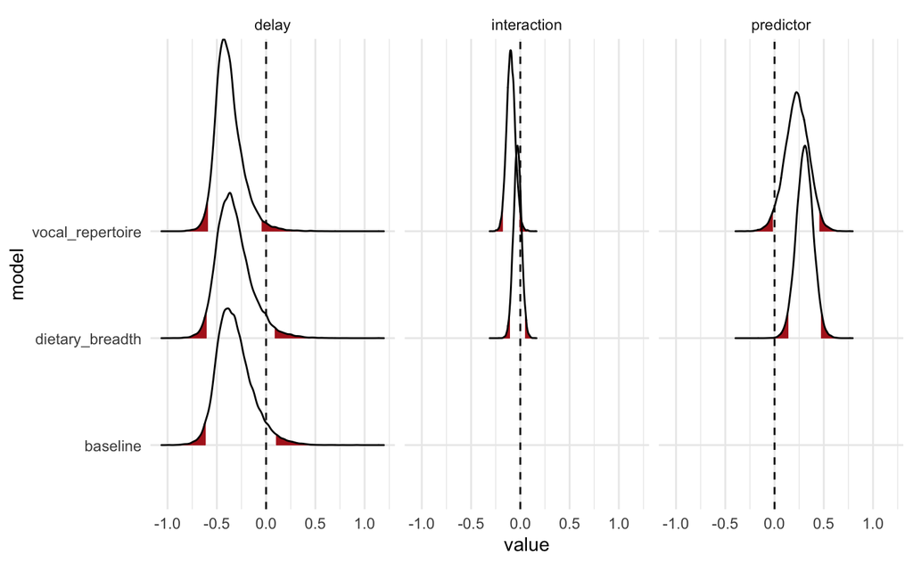

Performance estimate is the species intercept from the baseline model. Not sure if that makes sense.

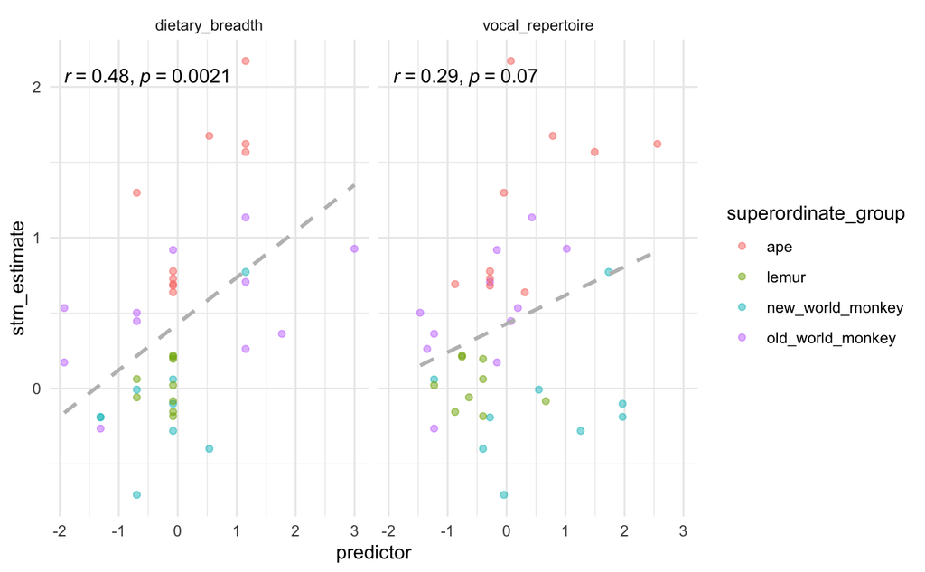

```r
base_model%>% spread_draws(r_species_english[species_english,term])%>%
  filter(term == "Intercept")%>%
  rename(stm_estimate = "r_species_english")%>%
  group_by(species_english)%>%
  median_qi(stm_estimate)%>%
  left_join(species_data%>%
              select(species_english,superordinate_group,vocal_repertoire,dietary_breadth))%>%
  pivot_longer(cols = c("vocal_repertoire","dietary_breadth"), names_to = "variable", values_to = "predictor")%>%
  ggplot(aes(x = predictor, y = stm_estimate, col = superordinate_group))+
  facet_grid(~variable)+
  geom_point(alpha = .5)+
  geom_smooth(method = lm, se = F, lty = 2, col = "grey")+
  stat_cor(method = "pearson", inherit.aes = F, aes(x = predictor, y = stm_estimate), r.accuracy = 0.01, cor.coef.name = "r")+
  theme_minimal()
```